# Maximizing the Log-Likelihood Function

# Does the starting value matter?

For binomial models, the short answer is no, not really. In the examples so far, we’ve started at $\beta = 0$ for all the $\beta$s. What if we’d started somewhere else? Figure 6 examines 5 different starting values:

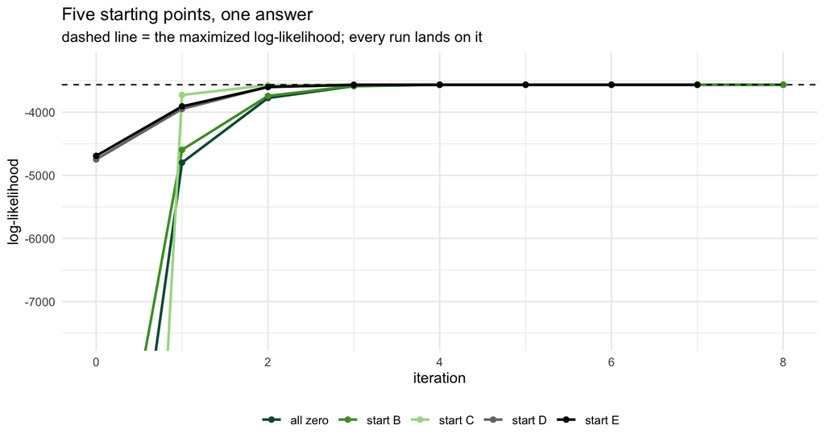

Figure 6

```r
# Five very different starting vectors, same destination. This is global
# concavity doing its job: one hill, one top, so it does not matter where on the
# hillside you begin.
climb <- function(start, maxit = 40) {
  bb <- start; out <- tibble(iter = 0, ll = loglik(bb, X, y))
  for (i in 1:maxit) {
    p  <- plogis(as.vector(X %*% bb))
    # guard: a wild enough start saturates every fitted probability, which drives
    # the weights to zero and leaves X'WX singular. Stop rather than error.
    st <- try(solve(t(X) %*% (X * (p * (1 - p))), t(X) %*% (y - p)), silent = TRUE)
    if (inherits(st, "try-error")) break
    bb <- bb + st
    out <- bind_rows(out, tibble(iter = i, ll = loglik(bb, X, y)))
    if (max(abs(st)) < 1e-8) break
  }
  out
}

set.seed(20260610)
starts <- list("all zero" = rep(0, ncol(X)),
               "start B"  = c(-1, 0.2, 0.5, 0.05),
               "start C"  = c(1, 0.1, -0.5, 0.03),
               "start D"  = c(-5, 0.5, 1.5, 0.1),
               "start E"  = c(-3, 0.2, -0.5, 0.06))

runs <- imap_dfr(starts, \(s, nm) climb(s) %>% mutate(start = nm))

ggplot(runs, aes(iter, ll, color = start)) +
  geom_line(linewidth = 0.9) + geom_point(size = 1.6) +
  geom_hline(yintercept = as.numeric(logLik(m)), linetype = "dashed", color = bu_black) +
  scale_color_manual(values = c(bu_green, bu_lightgreen, bu_palegreen, bu_grey, bu_black),
                     name = NULL) +
  coord_cartesian(ylim = c(as.numeric(logLik(m)) - 4000, as.numeric(logLik(m)) + 300)) +
  labs(title = "Five starting points, one answer",
       subtitle = "dashed line = the maximized log-likelihood; every run lands on it",
       x = "iteration", y = "log-likelihood") +
  theme_minimal() + theme(legend.position = "bottom")
```

Every model lands on the same log-likelihood, and recovers the same coefficients. This is because the binomial log-likelihood is globally concave: it is one hill with a single top, so it doesn’t matter which side of the hill you start on. For the models in this family, starting values are a convenience — they affect how many iterations you burn, not what you get.

This is a property of *the binomial* likelihood, not of maximum likelihood in general, and we’ll meet models later in the term where starting values matter a great deal.

Is it possible to choose starting values that will fail (that Newton-Raphson cannot reach a maximum from)? Sure, but this is why optimization algorithms always start somewhere sensible (zeros, or OLS estimates) and usually check whether the step they just took *improved* the function.

# Optimization packages

I wrote the loop out by hand to see inside it — to make the point that nothing magical happens between the data and the estimates. In practice, you’ll likely never do this, because you’ll use a built-in optimizer.

Base R’s `optim` is one such optimizer. You give it the function to maximize and a starting point; you tell it to maximize rather than minimize (it minimizes by default, so we flip the sign with `fnscale = -1`); and you ask it to return the Hessian at the solution, which gives us the standard errors the same way the hand-rolled loop did:

```r
o <- optim(rep(0, ncol(X)), loglik, X = X, y = y, method = "BFGS",
           control = list(fnscale = -1), hessian = TRUE)

tibble(term = colnames(X),
       optim_coef = round(o$par, 5),
       optim_se   = round(sqrt(diag(solve(-o$hessian))), 5))
```

```
# A tibble: 4 × 3
  term        optim_coef optim_se
  <chr>            <dbl>    <dbl>
1 (Intercept)    -3.24    0.103
2 lncaprat       -0.203   0.0238
3 border          0.783   0.0852
4 deml           -0.0784  0.00681
```

You’ll see we’ve achieved the same estimates as above. `optim` uses a “quasi-Newton method” (BFGS) that *approximates* the Hessian rather than computing it exactly — useful when the analytic second derivatives are painful, which is often. The `maxLik` package contains several optimization alternatives, useful if you have particularly difficult maximum likelihood problems.

# Recovering the model log-likelihood

One more quantity before we leave the maximizer: the maximized log-likelihood itself, the height of the hill at its top. We want it later for fit statistics like the log-likelihood ratio $\chi^2$, and for information criteria (AIC and BIC are both functions of it). It comes from the `glm` model with the `logLik` function, and to show there’s nothing mysterious in it we can rebuild it by hand — predicted probabilities, plugged into the log-likelihood, summed:

```r
pred      <- predict(m, type = "response")
ll_byhand <- sum(y * log(pred) + (1 - y) * log(1 - pred))

c(logLik = round(as.numeric(logLik(m)), 3),
  by_hand = round(ll_byhand, 3),
  from_our_loop = round(loglik(as.vector(b), X, y), 3))
```

```
       logLik       by_hand from_our_loop
    -3565.219     -3565.219     -3565.219
```

You’ll see these all report the same log-likelihood from the model we estimated above.

# Properties of MLEs

We have the estimates and the machinery that produced them. One thing is still owed: why believe any of it. The properties below justify maximum likelihood as an estimator, and each ties back to machinery we built rather than arriving as a separate act of faith.

- **Consistency.** As $n$ grows, $\widehat\beta$ converges to the true $\beta$. MLEs are not generally unbiased in small samples, but they are consistent — which is why “large $n$” reasoning runs through everything here. Defining *large* is not at all straightforward, and we’ll worry about it more than once this term.
- **Asymptotic normality.** Because the log-likelihood is locally quadratic at its peak, $\widehat\beta \sim N\big(\beta,\,(-H)^{-1}\big)$ in large samples — *whatever* distribution we assumed for $y$. Read that again: the coefficients are normally distributed even when the outcome is a binary, a count, or a duration. This is what licenses $z$-tests on coefficients from any ML model, and it is the local quadratic shape of the log-likelihood at its peak — the same curvature the likelihood notes turned into a standard error — restated as a sampling distribution. Those first two properties are claims about what happens across *repeated samples*, which is exactly the kind of claim a simulation can show you. In Figure 7 I generate 400 datasets at each of four sample sizes, fit a logit to every one, and collect the estimated slope.

[figure not shown]

Figure 7

```r
# Consistency and asymptotic normality in one picture. For each n, fit 400
# logits to fresh data from a known DGP and keep the slope. The dashed line is
# the truth; the black curve is the normal density implied by the mean and SD of
# the estimates themselves -- NOT fitted to the histogram, just drawn from them.

set.seed(20260610)
truth <- 1.0
reps  <- 400
ns    <- c(50, 200, 1000, 5000)

one_fit <- function(n) {
  x <- rnorm(n)
  y <- rbinom(n, 1, plogis(-0.3 + truth * x))
  coef(glm(y ~ x, family = binomial))[2]
}

sims <- map_dfr(ns, \(n) tibble(n = n, bhat = map_dbl(1:reps, \(i) one_fit(n)))) %>%
  mutate(n = factor(paste0("n = ", n), levels = paste0("n = ", ns)))

# The normal curve implied by each panel's own mean and SD -- drawn from the
# estimates, not fitted to the histogram.
norms <- sims %>%
  group_by(n) %>%
  reframe(bhat = seq(min(bhat), max(bhat), length.out = 200),
          dens = dnorm(seq(min(bhat), max(bhat), length.out = 200),
                       mean(bhat), sd(bhat)))

ggplot(sims, aes(bhat)) +
  geom_histogram(aes(y = after_stat(density)), bins = 34,
                 fill = bu_palegreen, color = "white", linewidth = 0.2) +
  geom_line(data = norms, aes(bhat, dens), color = bu_green, linewidth = 0.9) +
  geom_vline(xintercept = truth, linetype = "dashed", color = bu_black) +
  facet_wrap(~ n, scales = "free", nrow = 2) +
  labs(title = "Consistency and asymptotic normality, simulated",
       subtitle = paste0(reps, " logits per sample size; dashed line is the true slope of ", truth),
       x = expression("estimated slope," ~ hat(beta)), y = "density") +
  theme_minimal()
```

Three things to read off that figure, one for each property. First, the distributions **tighten** as $n$ grows — at $n = 50$ the estimates are scattered across a wide range, and by $n = 5000$ they are packed around the truth. That’s consistency: more data, less scatter, converging on the right answer.

Second, look carefully at the small-$n$ panel. The distribution is not centered on the dashed line; it sits a little to the right, and it’s visibly skewed. That is the small-sample bias of the MLE, and it’s the reason we say maximum likelihood estimators are *consistent* rather than unbiased. The bias doesn’t vanish because we were careful; it vanishes because $n$ got large.

Third, the shape. At the larger sample sizes the distributions are symmetric and bell-shaped — and remember what the outcome is. Every one of those models has a **binary** $y$, a variable that could not look less normal. The coefficients are normally distributed anyway. That is asymptotic normality, and it is what lets us put a $z$-statistic next to a logit, Poisson, or hazard coefficient without ever asking whether $y$ is normal.

- **Efficiency.** Among consistent, asymptotically normal estimators, the MLE attains the smallest asymptotic variance. See King, p. 80.
- **Invariance.** If $\widehat\beta$ is the MLE, then $g(\widehat\beta)$ is the MLE of $g(\beta)$ for continuous $g$. This is what the quantities-of-interest work relies on: we can transform coefficients into predicted probabilities, marginal effects, and other quantities, and they remain maximum likelihood estimates.

# Notes

- This file and the likelihood notes are a pair. There we built the log-likelihood and the two derivatives that describe it, and said what they tell us about the estimate and its precision; here we put them in a loop and watched it climb.
- Everything here was the binomial. Swapping the link and the distribution gives the maximizer for any model in the course — only `loglik`, the gradient, and the weights change. That is the next move, and it’s what the build-your-own-estimator work is about.
- The one-step figure and the Newton–Raphson animation both run on the intercept-only model — the same one-parameter hill we solved with algebra in the likelihood notes. Two treatments of one object: solve it outright, then climb it.

Back to top

## Footnotes

[^1]: I used Claude Code to generate Figures 1, 2, 3, and 7 in these slides.
[^2]: The correction term should look familiar: $(X'WX)^{-1}X'(y-\pi)$ has the shape of $(X'X)^{-1}X'y$, with the mistakes replacing the $y$ variable. Rescale those mistakes by the weights and it is exactly a weighted least-squares regression of them on $X$ — which is why the algorithm `glm` runs is called *iteratively reweighted least squares*.